# How to make a Nightingale’s rose plot with ggplotAssist

Keon-Woong Moon

2017-11-15

[figure not shown]

## Prerequisite

You have to install the developmental version of R package `editData` from github.

```r
#install.packages("devtools")
devtools::install_github("cardiomoon/editData")
```

## Install package

You can install `ggplotAssist` package from github.

```r
#install.packages("devtools")
devtools::install_github("cardiomoon/ggplotAssist")
```

## What is the rose plot?

A rose plot is a stacked bar plot with polar coordinate. With ggplot2, you can make the rose plot easily.

## Data

I will use the `rose` data included in package ggiraphExtra. The rose data is a phony dataset representing rose sales.

```r
library(ggiraphExtra)
head(rose)
```

```
     Month group value
1  January     G    10
2 February     G     5
3    March     G     7
4    April     G     9
5      May     G    11
6     June     G    13
```

Alternatively, you can download the `rose.csv` file from my github using the following code.

```r
library(readr)
url <- "https://raw.github.com/cardiomoon/ggplotAssistFigures/master/rose.csv"
rose=read_csv(url)
rose$Month=factor(rose$Month,levels=month.name)
```

## R code for rose plot

### 1. Make a bar plot

First, make a bar plot. In this plot the height of bar represent values in the data.

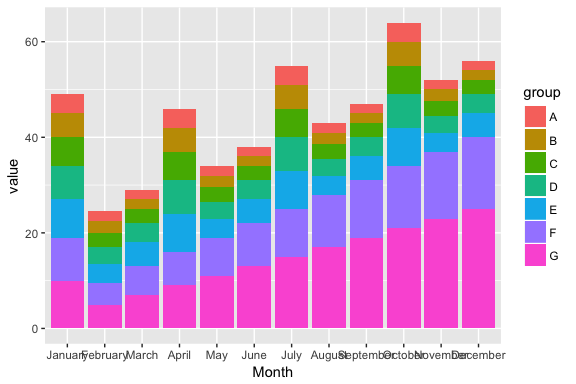

```r
require(ggplot2)
ggplot(data=rose,aes(x=Month,y=value,fill=group))+geom_bar(stat="identity")
```

### 2. Adjust options for bar graph

The default bar width is 0.9(90% of the resolution of data). To remove the spaces between the bars, set the width of bar 1 and the boundary color “black” and the thickness of line 0.1.

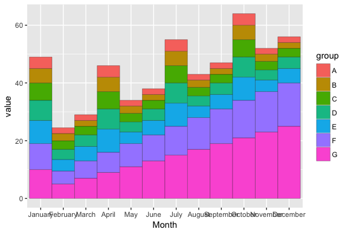

```r
ggplot(data=rose,aes(x=Month,y=value,fill=group))+
    geom_bar(stat="identity",width=1,color="black",size=0.1)
```

### 3. Apply polar coordinate

To make a rose plot, apply polar coordinate with coord_polar(). Apply “Reds” palette with scale_fill_brewer().

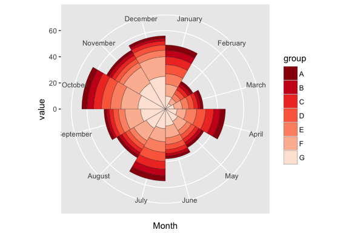

```r
ggplot(data=rose,aes(x=Month,y=value,fill=group))+
    geom_bar(stat="identity",width=1,color="black",size=0.1)+
    coord_polar()+
    scale_fill_brewer(palette="Reds",direction=-1)
```

## Make a rose plot with ggplotAssist - Standard method

1. In RStudio, Select File … New File…R script. To use data rose, highlight the data name `rose`(1). Execute ggplotAssist addin(arrow), to interactively manipulate it.

[figure not shown]

2. To mapping the variables, select `x` among aesthetics and `Month` among mapping. Select `y` among aesthetics and `value`. Select `fill`(1) and `group`(arow) to map the fill variable.

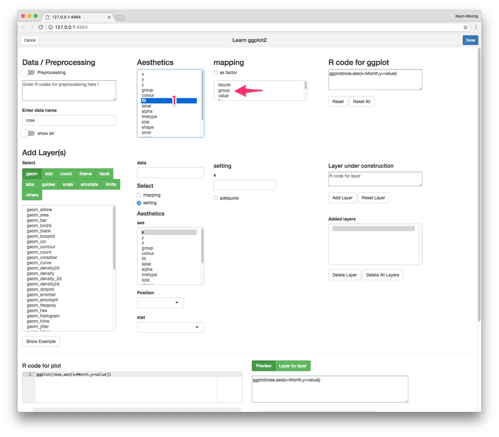

3. Press `geom` button(1). Select `geom_bar`(2). Select `identity` as stat(3). To set the color argument of geom_bar(), select `color`(4) and enter `black`(5) and select `addquote` checkbox(6). The R code for this layer is shown(7) and you can see the plot preview at lower right corner(8).

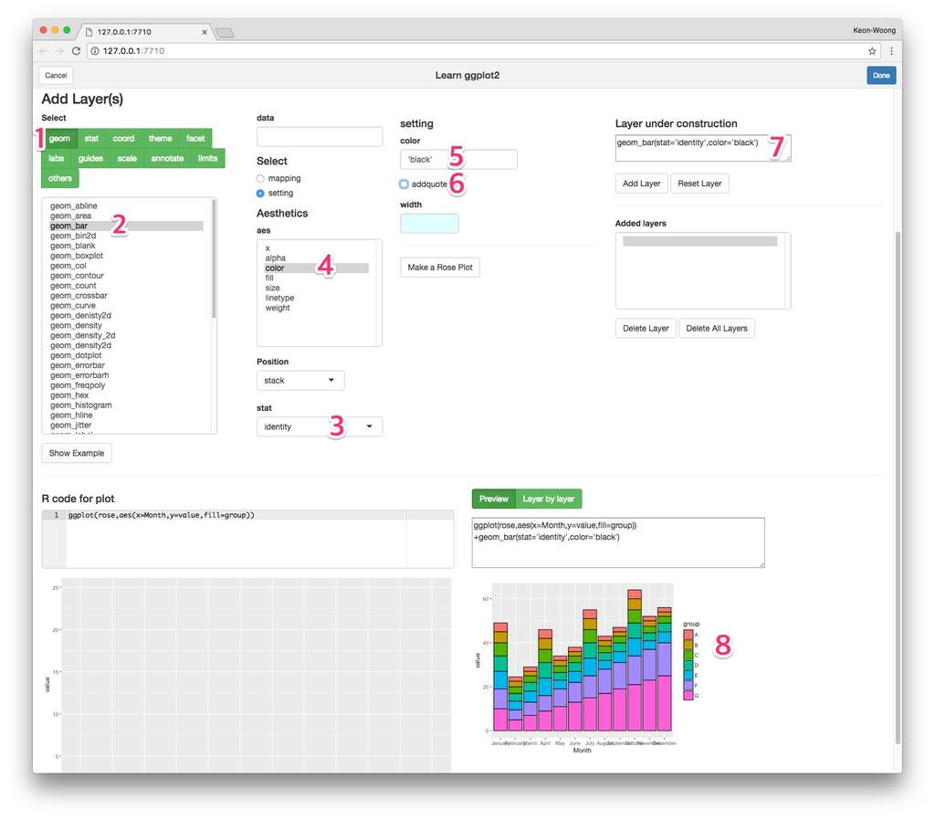

4. Set the `size`(9) of bar `0.1`(10). To remove the spaces between the bars, set the `width` of bar 1(11). You can see the R code for this layer(scarlet rectangle). Press `Add Layer` button to add this layer.

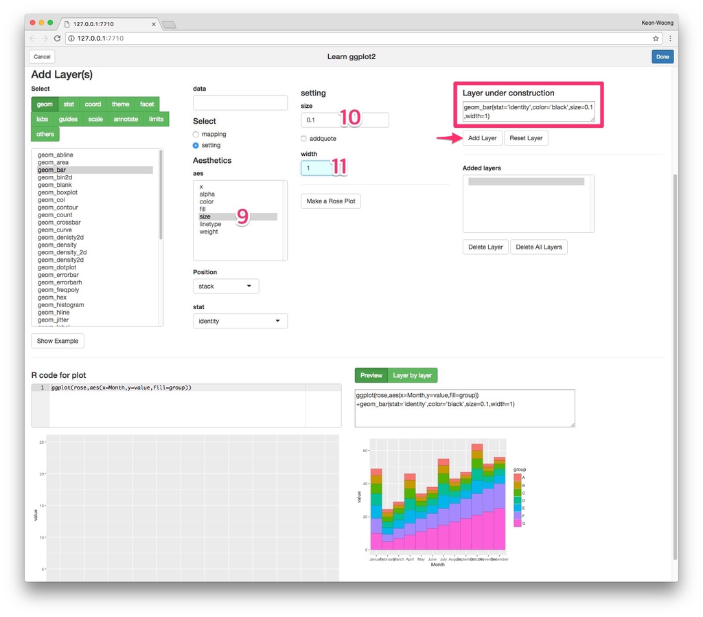

5. To apply `Reds` palette to this plot, press `scale` button(12). Select scale_fill_brewer(13) and select `Reds` palette(14) and set the direction of palette -1(15). Press `Add layer` button to add this layer(16).

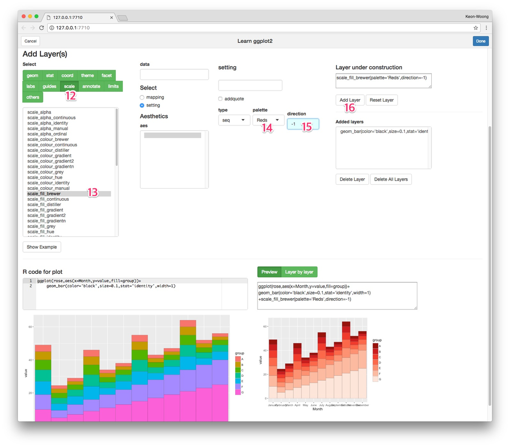

6. To apply ploar coordinate, press `coord` button(17). Select `coord_polar`(18) and press `Add Layer` button(19).

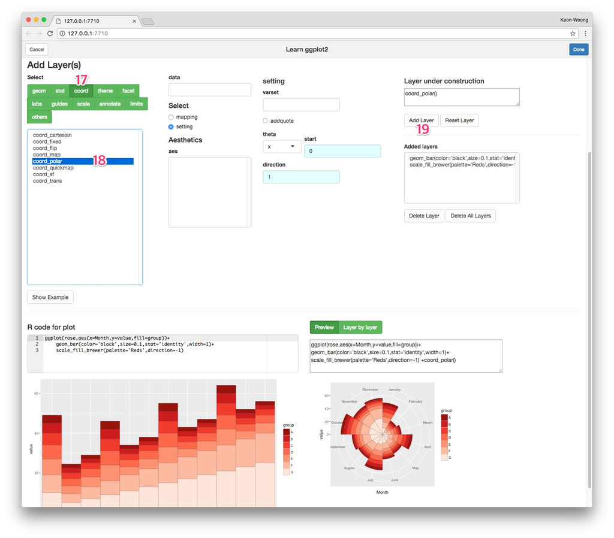

7. You can see the plot layer by layer. Press the `Layer by layer` button(20) and press the arrow head(arrow). You can see the plot layer by layer.

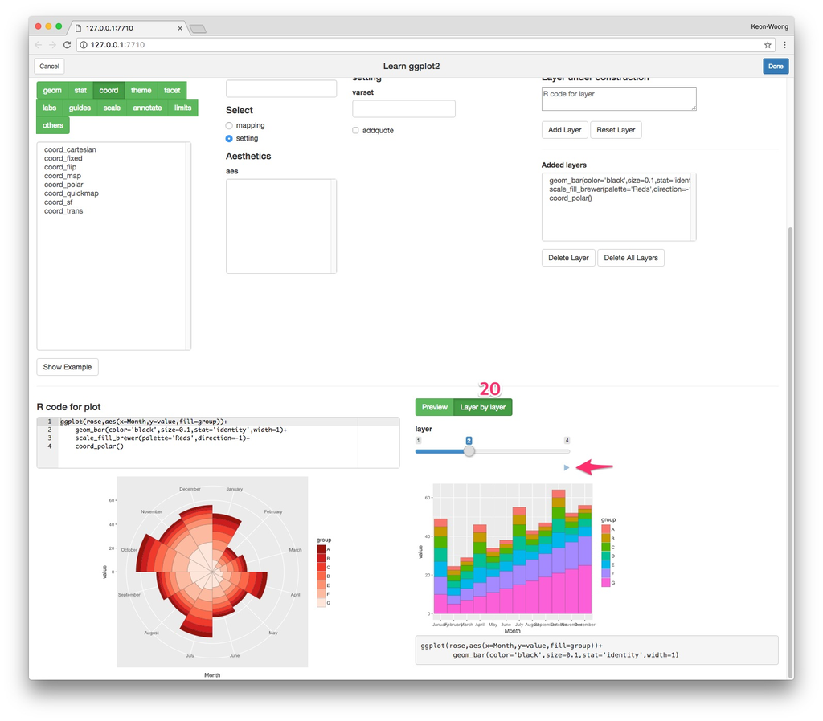

## Make a rose plot with ggplotAssist - A shortcut

1. After maaping the variables, press the `geom` button(1). Select `geom_bar`(2) among geoms and set the stat `identity`(3). You can see the R code for this layer(4) and the plot preview(5). Press the `Make a Rose Plot` button(6) and you can get the rose plot.

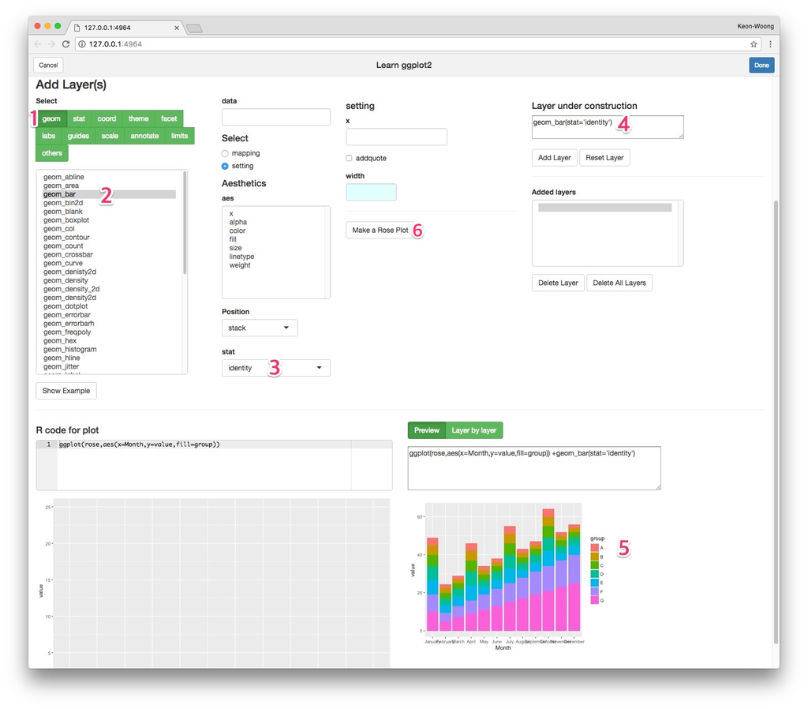

2. Press the `Done` button(arrow).

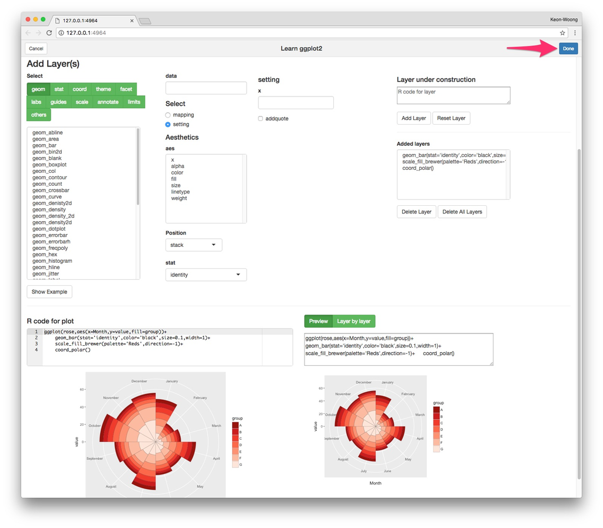

3. The code for the rose plot will be emitted at the cursor position(scarlet rectangle).

[figure not shown]